# Лабораторная работа 2. Кластерный анализ методом k-means

Natalia Korskova

2016-03-30

### Растения Армориканской возвышенности

#### Чтение и изучение данных

Считываем данные из файла:

```r
plants.01 <- read.table("plants.dat", header = TRUE, sep = ";")
```

Посмотрим на структуру данных и summary:

```r
str(plants.01)
```

```
## 'data.frame':    136 obs. of  32 variables:
##  $ plant.name: Factor w/ 136 levels "Aceca","Aceps",..: 1 2 3 4 5 6 7 8 9 10 ...
##  $ pdias     : num  96.84 110.72 0.06 0.08 1.48 ...
##  $ longindex : num  0 0 0.667 0.489 0.476 ...
##  $ durflow   : int  2 3 3 2 3 3 3 3 3 3 ...
##  $ height    : int  7 8 2 2 2 5 2 2 3 2 ...
##  $ begflow   : int  5 4 6 7 5 4 6 3 7 4 ...
##  $ mycor     : int  2 2 2 1 2 0 2 2 2 2 ...
##  $ vegaer    : int  0 0 0 2 2 0 0 0 0 0 ...
##  $ vegsout   : int  0 0 1 0 0 0 0 2 0 0 ...
##  $ autopoll  : int  0 0 0 0 1 3 3 1 0 2 ...
##  $ insects   : int  4 4 0 0 3 3 2 3 3 0 ...
##  $ wind      : int  0 0 4 4 0 0 0 0 0 3 ...
##  $ lign      : int  1 1 0 0 0 0 0 0 0 0 ...
##  $ piq       : int  0 0 0 0 0 0 0 0 0 0 ...
```

[output cut: 18 more lines]

```r
summary(plants.01)
```

```
##    plant.name      pdias            longindex         durflow
##  Aceca  :  1   Min.   :   0.010   Min.   :0.0000   Min.   : 1.000
##  Aceps  :  1   1st Qu.:   0.460   1st Qu.:0.0000   1st Qu.: 2.000
##  Agrca  :  1   Median :   1.575   Median :0.4444   Median : 3.000
##  Agrst  :  1   Mean   :  70.764   Mean   :0.4060   Mean   : 3.184
##  Ajure  :  1   3rd Qu.:   8.505   3rd Qu.:0.7230   3rd Qu.: 4.000
##  Allpe  :  1   Max.   :1684.300   Max.   :1.0000   Max.   :12.000
##  (Other):130   NA's   :36         NA's   :25
##      height         begflow          mycor           vegaer
##  Min.   :1.000   Min.   :1.000   Min.   :0.000   Min.   :0.0000
##  1st Qu.:2.000   1st Qu.:4.000   1st Qu.:1.000   1st Qu.:0.0000
##  Median :4.000   Median :5.000   Median :2.000   Median :0.0000
##  Mean   :4.118   Mean   :5.169   Mean   :1.598   Mean   :0.2164
##  3rd Qu.:5.000   3rd Qu.:6.000   3rd Qu.:2.000   3rd Qu.:0.0000
##  Max.   :8.000   Max.   :9.000   Max.   :2.000   Max.   :2.0000
##                                  NA's   :39      NA's   :2
##     vegsout          autopoll         insects           wind
##  Min.   :0.0000   Min.   :0.0000   Min.   :0.000   Min.   :0.0000
##  1st Qu.:0.0000   1st Qu.:0.0000   1st Qu.:0.000   1st Qu.:0.0000
##  Median :0.0000   Median :0.0000   Median :3.000   Median :0.0000
##  Mean   :0.4254   Mean   :0.8897   Mean   :2.022   Mean   :0.9853
##  3rd Qu.:1.0000   3rd Qu.:2.0000   3rd Qu.:3.000   3rd Qu.:3.0000
##  Max.   :2.0000   Max.   :3.0000   Max.   :4.000   Max.   :4.0000
##  NA's   :2
##       lign             piq             ros             semiros
##  Min.   :0.0000   Min.   :0.000   Min.   :0.00000   Min.   :0.0000
##  1st Qu.:0.0000   1st Qu.:0.000   1st Qu.:0.00000   1st Qu.:0.0000
##  Median :0.0000   Median :0.000   Median :0.00000   Median :0.0000
##  Mean   :0.3162   Mean   :0.125   Mean   :0.09091   Mean   :0.2652
##  3rd Qu.:1.0000   3rd Qu.:0.000   3rd Qu.:0.00000   3rd Qu.:1.0000
##  Max.   :1.0000   Max.   :1.000   Max.   :1.00000   Max.   :1.0000
##                                   NA's   :4         NA's   :4
##      leafy            suman            winan            monocarp
##  Min.   :0.0000   Min.   :0.0000   Min.   :0.00000   Min.   :0.00000
##  1st Qu.:0.0000   1st Qu.:0.0000   1st Qu.:0.00000   1st Qu.:0.00000
##  Median :1.0000   Median :0.0000   Median :0.00000   Median :0.00000
##  Mean   :0.6439   Mean   :0.1397   Mean   :0.08824   Mean   :0.06618
##  3rd Qu.:1.0000   3rd Qu.:0.0000   3rd Qu.:0.00000   3rd Qu.:0.00000
##  Max.   :1.0000   Max.   :1.0000   Max.   :1.00000   Max.   :1.00000
##  NA's   :4
```

[output cut: 9 more lines]

```
##  Min.   :0.0000   Min.   :0.0000   Min.   :0.0000   Min.   :0.0000
##  1st Qu.:0.0000   1st Qu.:0.0000   1st Qu.:0.0000   1st Qu.:0.0000
##  Median :0.0000   Median :0.0000   Median :0.0000   Median :0.0000
##  Mean   :0.4091   Mean   :0.1515   Mean   :0.0916   Mean   :0.2901
##  3rd Qu.:1.0000   3rd Qu.:0.0000   3rd Qu.:0.0000   3rd Qu.:1.0000
##  Max.   :1.0000   Max.   :1.0000   Max.   :1.0000   Max.   :1.0000
##  NA's   :4        NA's   :4        NA's   :5        NA's   :5
##      epizoo           aquat            windgl            unsp
##  Min.   :0.0000   Min.   :0.0000   Min.   :0.0000   Min.   :0.0000
##  1st Qu.:0.0000   1st Qu.:0.0000   1st Qu.:0.0000   1st Qu.:0.0000
##  Median :0.0000   Median :0.0000   Median :0.0000   Median :0.0000
##  Mean   :0.1679   Mean   :0.0229   Mean   :0.1756   Mean   :0.2901
##  3rd Qu.:0.0000   3rd Qu.:0.0000   3rd Qu.:0.0000   3rd Qu.:1.0000
##  Max.   :1.0000   Max.   :1.0000   Max.   :1.0000   Max.   :1.0000
##  NA's   :5        NA's   :5        NA's   :5        NA's   :5
```

В выборке наблюдаются различные растения, каждый с уникальным plant.name, для которых изучается влияние человеческой деятельности на растения. Величина pdias отвечает за массу диаспоры – части растения различной морфологической природы (спора, семя, плод, клубень и т. п.), естественно отделяющаяся от материнского организма и служащая для размножения и расселения. Для этой величины 36 пропущенных значений. Величина longindex отвечает за срок всхожести семян, здесь 25 пропущенных значений. Остальные значения хоть и распознаны как int, на самом деле являются факторами – либо бинарными и принимают значения 0 или 1, либо имеют несколько уровней: от 1 до 8, от 1 до 9, от 0 до 4 и т.д. Отдельно обратим внимание на mycor – наличие микоризы (симбиотическая ассоциация мицелия гриба с корнями высших растений). Этот фактор принимает значение 0, если микоризы никогда не бывает, 1 – если бывает иногда, 2 – если всегда. Для этой величины 39 пропущенных значений – почти треть всех наблюдений. Посмотрим на описательные статистики выборки, задав нужные типы данных при чтении:

```r
plants.factor <- read.table("plants.dat", header = TRUE, sep = ";", colClasses = c("character", "numeric", "numeric", rep("factor", 29)))
summary(plants.factor)
```

```
##   plant.name            pdias            longindex         durflow
##  Length:136         Min.   :   0.010   Min.   :0.0000   3      :47
##  Class :character   1st Qu.:   0.460   1st Qu.:0.0000   2      :46
##  Mode  :character   Median :   1.575   Median :0.4444   4      :23
##                     Mean   :  70.764   Mean   :0.4060   5      : 8
##                     3rd Qu.:   8.505   3rd Qu.:0.7230   1      : 4
##                     Max.   :1684.300   Max.   :1.0000   6      : 3
##                     NA's   :36         NA's   :25       (Other): 5
##      height      begflow    mycor     vegaer    vegsout   autopoll insects
##  2      :32   5      :42   0   :10   0   :117   0   :96   0:73     0:41
##  3      :26   6      :39   1   :19   1   :  5   1   :19   1:26     1:11
##  5      :22   4      :19   2   :68   2   : 12   2   :19   2:16     2: 5
##  4      :21   7      :15   NA's:39   NA's:  2   NA's: 2   3:21     3:62
##  8      :16   3      :12                                           4:17
##  6      : 7   2      : 3
##  (Other):12   (Other): 6
##  wind   lign   piq       ros      semiros    leafy    suman   winan
##  0:95   0:93   0:119   0   :120   0   :97   0   :47   0:117   0:124
##  1: 2   1:43   1: 17   1   : 12   1   :35   1   :85   1: 19   1: 12
##  2: 2                  NA's:  4   NA's: 4   NA's: 4
##  3:20
##  4:17
##
##
##  monocarp polycarp seasaes   seashiv    seasver    everalw   everparti
##  0:127    0: 19    0   :85   0   :128   0   :126   0   :78   0   :112
##  1:  9    1:117    1   :47   1   :  4   1   :  6   1   :54   1   : 20
##                    NA's: 4   NA's:  4   NA's:  4   NA's: 4   NA's:  4
##
##
##
##
##   elaio     endozoo    epizoo     aquat      windgl      unsp
##  0   :119   0   :93   0   :109   0   :128   0   :108   0   :93
##  1   : 12   1   :38   1   : 22   1   :  3   1   : 23   1   :38
##  NA's:  5   NA's: 5   NA's:  5   NA's:  5   NA's:  5   NA's: 5
##
##
##
##
```

Для фактора, отвечающему за наличие микоризы, только в 10 случаях из примерно 100 (которые не NA) микоризы нет. Это похоже на данные по генеральной совокупности всех растений: симбионт с грибами есть у всех голосеменных растений, у примерно 70% однодольных и 80—90% двудольных. Поэтому отбросим этот фактор как имеющий большое количество пропущенных значений. По причине большой пропущенности значений придётся отбросить и величины pdias и longindex. Величины, для которых количество пропущенных значений 5 и менее, остаются в выборке.

```r
plants.02 <- subset(plants.01, select = -c(2, 3, 7))
```

#### Нормализация данных

В оставшей выборке помимо названий растений остальные величины являются факторами, поэтому будем рассматривать нормализацию методом feature-scaling с максимумом 1:

```r
normalize <- function(x) {
    return ((x - min(na.omit(x))) / (max(na.omit(x)) - min(na.omit(x))))
  }

plants.02.fs <- as.data.frame(lapply(plants.02[, 2:29], normalize))
```

Чтобы не терять наблюдения, заменим NA в тех столбцах, где оно встречается редко (менее 5 раз) на среднее по всему столбцу:

```r
for(i in 1:ncol(plants.02.fs)){
  plants.02.fs[is.na(plants.02.fs[,i]), i] <- mean(plants.02.fs[,i], na.rm = TRUE)
}
```

#### Кластеризация:

Зададим начальное число для генератора случайных чисел и формат вывода чисел:

```r
set.seed(1)
options(digits=2)
```

Попробуем найти оптимальное число кластеров, перебирая числа от 2 до 10. Хотя данных много, ограничимся 10 кластерами как максимальным числом, иначе будет непросто интерпретировать результат.

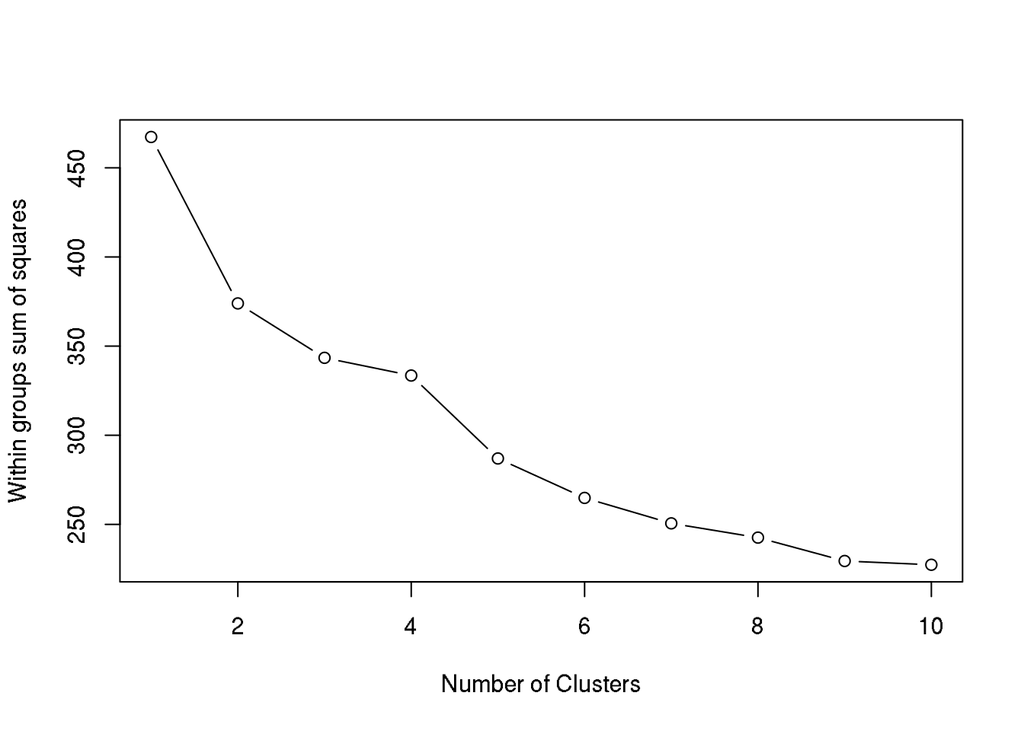

```r
wss <- (nrow(plants.02.fs-1))*sum(apply(plants.02.fs,2,var))
for (i in 2:10) wss[i] <- kmeans(plants.02.fs,
   centers=i)$tot.withinss
plot(1:10, wss, type="b", xlab="Number of Clusters",
  ylab="Within groups sum of squares")
```

Перспективным выглядит разбиение на 5 кластеров – до 5 сумма падает достаточно резко, после 5 – не настолько. Аналогично стоит рассмотреть 3 кластера, т.к. до 3 падение резкое, а сразу после – не очень. Полученные наблюдения хорошо соотносятся с исследованием набора данных при помощи иерархического анализа – неплохие результаты получались при 3 и 5 кластерах. Посмотрим, как сработает метод k-means для такого числа кластеров.

```r
cl_3 <- kmeans(na.omit(plants.02.fs), 3, iter.max = 100)
cl_3$size
```

```
## [1] 51 48 37
```

Размеры кластеров получились не очень равномерные: третий заметно меньше первых двух. Разбиение на 5 кластеров:

```r
cl_5 <- kmeans(na.omit(plants.02.fs), 5, iter.max = 100)
cl_5$size
```

```
## [1] 27 35 12 43 19
```

Тоже не очень равномерно.

#### Интерпретация результатов

Рассмотрим центры при разбиении на 3 кластера:

```r
t(cl_3$centers)
```

```
##               1      2      3
## durflow   0.191 0.1420 0.2826
## height    0.230 0.7530 0.3436
## begflow   0.512 0.4766 0.5912
## vegaer    0.206 0.0566 0.0405
## vegsout   0.147 0.1859 0.3378
## autopoll  0.275 0.1389 0.5315
## insects   0.431 0.6302 0.4459
## wind      0.358 0.1979 0.1554
## lign      0.000 0.8958 0.0000
## piq       0.020 0.2708 0.0811
## ros       0.219 0.0000 0.0319
## semiros   0.540 0.0000 0.2305
## leafy     0.241 1.0000 0.7375
## suman     0.020 0.0000 0.4865
## winan     0.020 0.0000 0.2973
## monocarp  0.118 0.0000 0.0811
## polycarp  0.961 1.0000 0.5405
## seasaes   0.039 0.6398 0.4247
## seashiv   0.000 0.0013 0.1097
## seasver   0.098 0.0227 0.0025
## everalw   0.843 0.2254 0.0491
## everparti 0.020 0.1105 0.3866
## elaio     0.119 0.0625 0.0910
## endozoo   0.045 0.7500 0.0314
## epizoo    0.317 0.0000 0.1803
## aquat     0.059 0.0000 0.0025
## windgl    0.121 0.1875 0.2352
## unsp      0.378 0.0625 0.4638
```

Первый кластер отличается от двух других тем, что у него высокие показатели следующих значений: vegaer, wind, ros, everalw, elaio, epizoo. Во втором кластере выделяются следующие значения: height, lign, leafy, seasaes, endozoo. В третьем кластере выделяются такие значения: autopoll, suman, winam, seashiv, everparti, unsp. Обращаясь к расшифровке значений, можно так охарактеризовать кластеры: первый кластер характеризуется тем, что здесь есть розоцветные, плоды внутренние, вечнозелёные с воздушным вегетативным распространением. Во второй кластер попали самые высокие растения, которые являются лиственными деревьями (lign и leafy). Кроме того, плоды спрятаны. Кратко – это деревья. В третьем кластере самоопыляемые, с летним периодом цветения, часто и зимний период цветения, частично вечнозелёные, неспецифичный механизм распространения семян.

Интерпретация разбиения на 5 кластеров:

```r
t(cl_5$centers)
```

```
##               1      2     3      4      5
## durflow   0.195 0.1818 0.220 0.1438 0.3445
## height    0.243 0.3469 0.190 0.7841 0.3083
## begflow   0.519 0.5929 0.500 0.4564 0.5526
## vegaer    0.185 0.1429 0.167 0.0632 0.0000
## vegsout   0.111 0.4429 0.208 0.1727 0.0263
## autopoll  0.210 0.2857 0.222 0.1473 0.8246
## insects   0.380 0.4929 0.646 0.6163 0.3684
## wind      0.407 0.3000 0.062 0.2151 0.1053
## lign      0.000 0.0857 0.000 0.9302 0.0000
## piq       0.037 0.0857 0.000 0.2791 0.0526
## ros       0.000 0.0052 1.000 0.0000 0.0096
## semiros   1.000 0.0152 0.000 0.0000 0.4490
## leafy     0.000 0.9797 0.000 1.0000 0.5415
## suman     0.037 0.0000 0.000 0.0000 0.9474
## winan     0.037 0.0000 0.000 0.0000 0.5789
## monocarp  0.222 0.0000 0.000 0.0000 0.1579
## polycarp  0.926 1.0000 1.000 1.0000 0.1053
## seasaes   0.074 0.2286 0.083 0.7142 0.3533
## seashiv   0.000 0.0000 0.000 0.0014 0.2137
## seasver   0.074 0.0286 0.250 0.0021 0.0048
## everalw   0.852 0.4571 0.583 0.1818 0.0957
## everparti 0.000 0.2571 0.083 0.1001 0.3317
## elaio     0.111 0.1195 0.250 0.0233 0.0671
## endozoo   0.000 0.0737 0.167 0.7907 0.0458
## epizoo    0.296 0.2667 0.250 0.0000 0.1318
## aquat     0.111 0.0013 0.000 0.0000 0.0036
## windgl    0.111 0.1815 0.250 0.1860 0.1856
## unsp      0.407 0.4166 0.167 0.0233 0.5721
```

В первом кластере все растения полурозоцветные и больше всего вечнозелёных, многократно плодоносящих. Во втором больше всего vegsout – подземное вегетативное размножение, растения лиственные, но не деревья. Во третьем кластере совсем нет растений с колючками (piq), растения самые невысокие (деревьями не являются, что логично), все многократно плодоносят, опыление часто происходит насекомыми и почти никогда с помощью ветра (в отличие от других класеров), летнего и зимнего цветения нет. В четвёртом кластере самые высокие лиственные растения, плоды которых разносятся ветром и являются внутренними – это деревья. В пятом кластере мало многократно плодоносящих растений (polycarp) и много самоопыляющихся, почти все цветут летом и около половины зимой (сильно больше, чем в других кластерах).